# Expressing Uncertainty

2022-10-21

Expressing Uncertainty (15 points)

Topics to Cover:

Incorporating Data Variability in Graphs Make sure to include:

(4 points) An introductory statement with the goal of the section (in your own words) and a brief description of the data set and variables you will be using.

(11 points) R code chunks interspersed with some text descriptions about the code you have written and with text description about each topic. For this section, you should actually make a graph (and not simply find an example already online like we looked at for hurricane graphs).

This covers how to visualize data with variability so as not to exclude variability from the visual. I will use the gun violence data set, which has mortality and ownership rates of guns by state and region in America.

```r
library(tidyverse)
guns <- read_csv("data/gun_violence_us.csv")
```

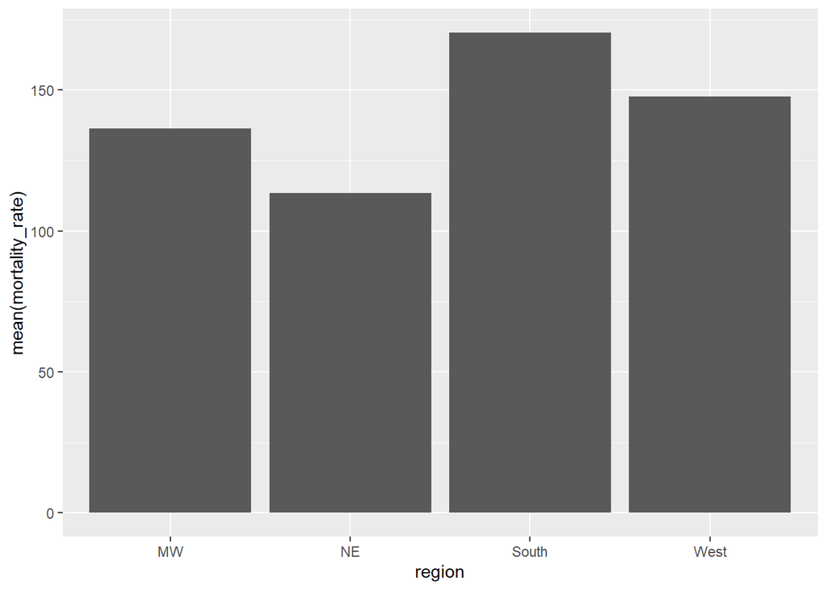

```r
ggplot(data = guns, aes(x = region, y = mean(mortality_rate))) +
  geom_col()
```

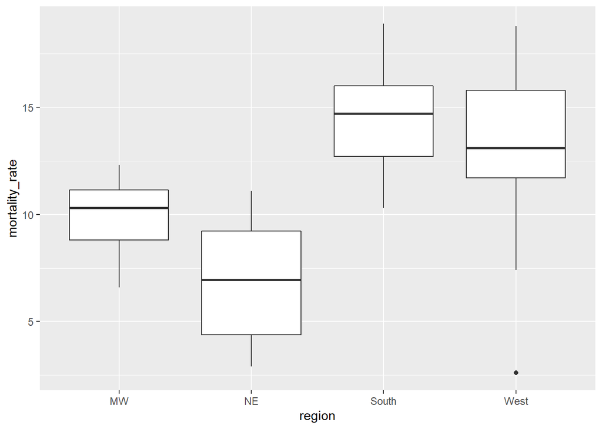

```r
ggplot(data = guns, aes(x = region, y = mortality_rate)) +
  geom_boxplot()
```